# *Análisis comparativo de los salarios de Data Science entre 2020-2023 a nivel internacional*

**Variable trabajo remoto**

La relación remota consta de 3 valores:

- 0 : Sin trabajo remoto (menos del 20 %)
- 50 : Parcialmente remoto
- 100 : Totalmente remoto (más del 80 %)

```r
library(modeest)
mfv(muestra$remote_ratio)
```

```
## [1] 0
```

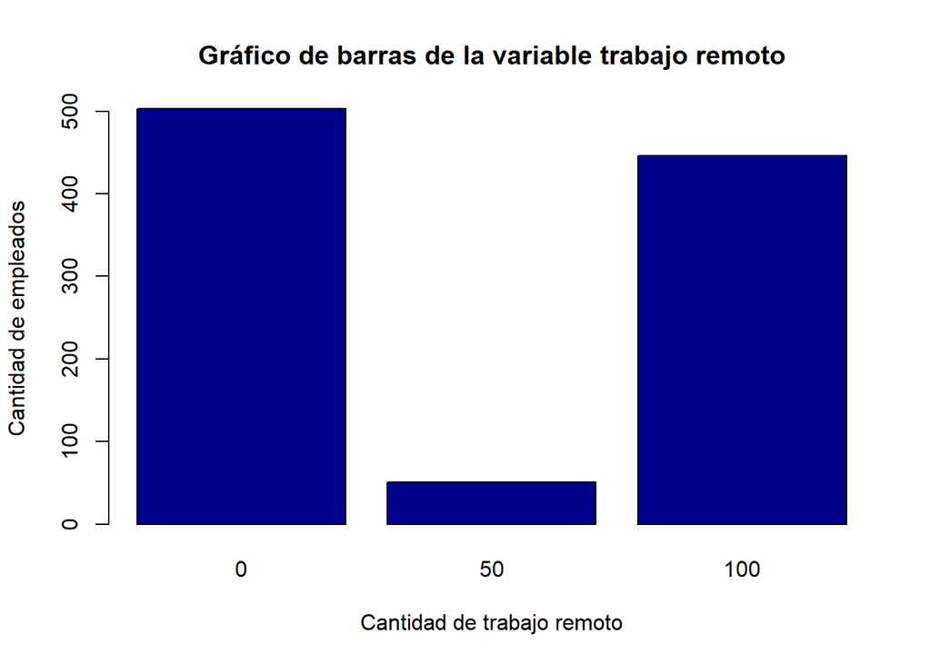

```r
barplot(table(muestra$remote_ratio),main="Gráfico de barras de la variable trabajo remoto",col="darkblue",xlab = "Cantidad de trabajo remoto",ylab = "Cantidad de empleados")
```

Del grafico inferimos que los empleados de Data Science que no tienen trabajo remoto es mayor en comparación al numero de los que trabajan de manera Totalmente remota y los que tienen un trabajo Parcialmente remoto es mucho menor. La tendencia indica que la mayoría de los empleados no trabajan de manera remota o no tienen una cantidad considerable de trabajo remoto.

**Variable país del empleo**

```r
library(modeest)
mfv(muestra$company_location)
```

```
## [1] "US"
```

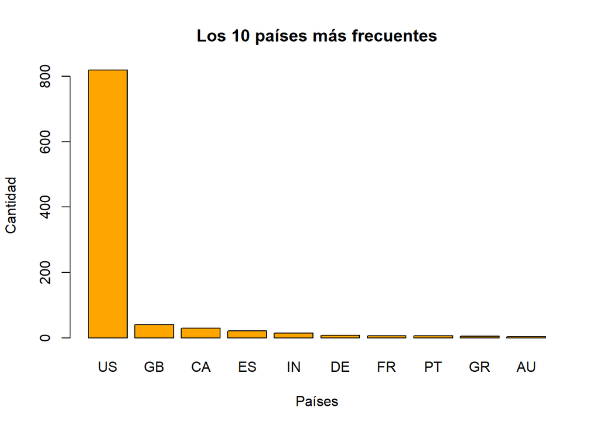

```r
fr2 <- table(muestra$company_location)
top2 <- names(sort(fr2, decreasing = T))[1:10]
barplot(fr2[top2], main = "Los 10 países más frecuentes", xlab = "Países", ylab = "Cantidad", col="orange")
```

**Variable tamaño de la compañía**

Hay que tener 3 consideraciones:

- S, que se refiere a pequeña empresa (empresas de hasta 50 empleados)
- M, que hace referencia a mediana empresa (mas de 50 empleados hasta 100)
- L, que se refiere a gran empresa (mas de 100)

```r
library(modeest)
mfv(muestra$company_size)
```

```
## [1] "M"
```

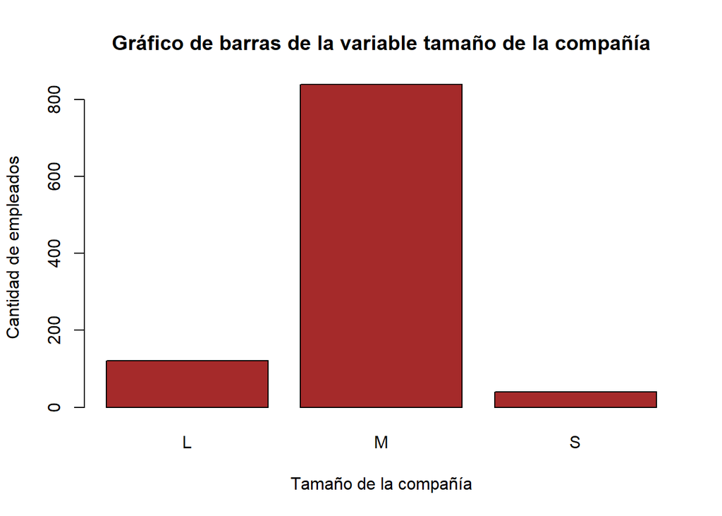

```r
barplot(table(muestra$company_size),main="Gráfico de barras de la variable tamaño de la compañía",col="brown",xlab = "Tamaño de la compañía",ylab = "Cantidad de empleados")
```

Del gráfico inferimos que hay una gran concentración de empleados trabajando en medianas empresas donde la cantidad de empleados va de 50 a 100 empleados y en los dos tipos de empresas la cantidad de empleados es menor.

## 2.4 Limpieza de base de datos

Al seleccionar un dataset previamente desarrollado, se evitó algún tipo de problema con respecto a la formulación de preguntas.

```r
any(is.na(muestra)) #Verificamos si hay valores faltantes en el dataset
```

```
## [1] FALSE
```

```r
sum(!complete.cases(muestra)) #Casos incompletos
```

```
## [1] 0
```

# 3 **Análisis descriptivo**

## 3.1 Salario en dólares - Nivel de experiencia

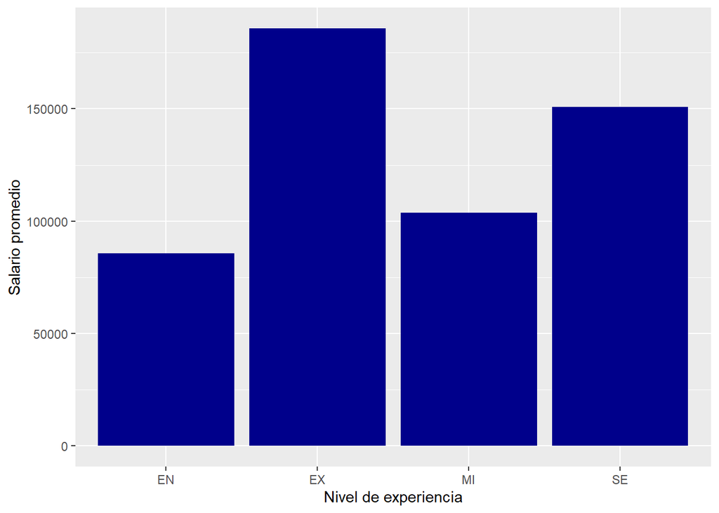

```r
#Gráfico de barras
library(ggplot2)
ggplot(muestra, aes(x = experience_level, y = salary_in_usd)) +  stat_summary(fun = "mean", geom = "bar", fill = "darkblue") + xlab("Nivel de experiencia") + ylab("Salario promedio")
```

```r
#Análisis del modelo lienal
modelo1 <- lm(salary_in_usd ~ experience_level, data = muestra)
summary(modelo1)
```

```
##
## Call:
## lm(formula = salary_in_usd ~ experience_level, data = muestra)
##
## Residuals:
##     Min      1Q  Median      3Q     Max
## -170711  -38820   -5793   35107  327147
##
## Coefficients:
##                    Estimate Std. Error t value Pr(>|t|)
## (Intercept)           85665       6392  13.403  < 2e-16 ***
## experience_levelEX   100046      12183   8.212  6.7e-16 ***
## experience_levelMI    18155       7560   2.401   0.0165 *
## experience_levelSE    65128       6746   9.654  < 2e-16 ***
## ---
## Signif. codes:  0 '***' 0.001 '**' 0.01 '*' 0.05 '.' 0.1 ' ' 1
##
## Residual standard error: 56810 on 996 degrees of freedom
## Multiple R-squared:  0.1637, Adjusted R-squared:  0.1612
## F-statistic: 64.97 on 3 and 996 DF,  p-value: < 2.2e-16
```

## 3.2 Salario en dólares - País del empleado

```r
#Promedio por países
aggregate(salary_in_usd ~ employee_residence, data = muestra, FUN = mean)
```

```
##    employee_residence salary_in_usd
## 1                  AT      91237.00
## 2                  AU      45050.00
## 3                  BE      82744.00
## 4                  BO      75000.00
## 5                  BR      31034.20
## 6                  CA     126678.28
## 7                  CF      54685.00
## 8                  CH      56536.00
## 9                  CL      40038.00
## 10                 CR      20000.00
## 11                 DE      78741.25
## 12                 DK      45896.00
## 13                 DZ     100000.00
## 14                 EE      31520.00
```

[output cut: 29 more lines]

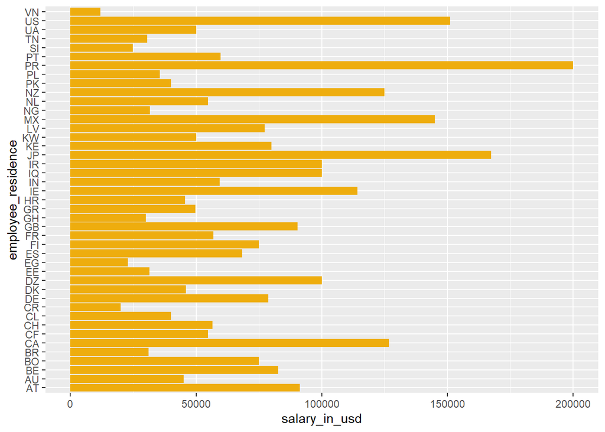

```r
library(ggplot2)
ggplot(data = muestra, aes(x = employee_residence, y = salary_in_usd)) +
  stat_summary(fun = mean, geom = "bar", fill="#EEAD0E") +
  coord_flip()
```

## 3.3 Tamaño de la compañía - Salario en dólares

```r
#Salario promedio en dólares dependiendo el tamaño de la compañía
aggregate(salary_in_usd ~ company_size, data = muestra, FUN = mean)
```

```
##   company_size salary_in_usd
## 1            L     112737.08
## 2            M     143111.67
## 3            S      92072.35
```

```r
#Modelo de regresión lineal relacionado ambas variables
modelo2 <- lm(salary_in_usd ~ company_size, data = muestra)
summary(modelo2)
```

```
##
## Call:
## lm(formula = salary_in_usd ~ company_size, data = muestra)
##
## Residuals:
##     Min      1Q  Median      3Q     Max
## -128112  -43112   -2724   37263  287855
##
## Coefficients:
##               Estimate Std. Error t value Pr(>|t|)
## (Intercept)     112737       5508  20.467  < 2e-16 ***
## company_sizeM    30375       5892   5.155 3.05e-07 ***
## company_sizeS   -20665      11051  -1.870   0.0618 .
## ---
## Signif. codes:  0 '***' 0.001 '**' 0.01 '*' 0.05 '.' 0.1 ' ' 1
##
## Residual standard error: 60590 on 997 degrees of freedom
## Multiple R-squared:  0.04765,    Adjusted R-squared:  0.04574
## F-statistic: 24.94 on 2 and 997 DF,  p-value: 2.686e-11
```

## 3.4 País del empleado - Tamaño de la compañía

Como resultado de una relación entre estas dos variables, podemos observar que en ciertos países hay una mayor presencia de medianas y largas empresas, lo cual nos indica que dependiendo del país, existe una mayor solidez y crecimiento de las empresas, con lo cual, se permite un mejor proceso de selección de personal y un mejor desarrollo para lograr objetivos y metas.

```r
tablaC <- table(muestra$employee_residence, muestra$company_size)
print(tablaC)
```

```
##
##        L   M   S
##   AT   0   0   1
##   AU   1   0   0
##   BE   0   1   0
##   BO   0   1   0
##   BR   1   2   2
##   CA   5  19   1
##   CF   0   1   0
##   CH   0   0   1
##   CL   1   0   0
##   CR   0   1   0
##   DE   1   4   3
##   DK   0   0   1
##   DZ   0   1   0
##   EE   0   0   1
##   EG   0   1   0
##   ES   2  21   1
##   FI   0   1   0
##   FR   3   4   1
##   GB   2  38   1
##   GH   0   0   1
##   GR   2   4   0
##   HR   0   0   1
##   IE   1   1   1
##   IN  11   5   2
##   IQ   0   0   1
##   IR   0   1   0
##   JP   0   0   3
##   KE   0   0   1
##   KW   1   0   0
##   LV   0   2   0
##   MX   1   2   0
##   NG   2   1   0
##   NL   4   0   0
##   NZ   0   0   1
##   PK   0   1   0
##   PL   3   0   1
##   PR   0   1   0
##   PT   3   4   0
##   SI   1   0   0
##   TN   0   1   0
##   UA   0   0   1
##   US  75 721  14
##   VN   1   0   0
```

## 3.5 Tipo de empleo - Trabajo remoto

Relacionamos la cantidad de trabajo remoto con respecto a los cuatro tipos de empleo que encontramos: Tiempo Parcial, Tiempo Completo, Con contrato e Independiente.

```r
tablaC1 <- table(muestra$employment_type, muestra$remote_ratio)
tablaC1
```

```
##
##        0  50 100
##   CT   0   0   6
##   FL   0   1   1
##   FT 503  49 437
##   PT   0   1   2
```